# sklearn.discriminant_analysis.QuadraticDiscriminantAnalysis

**class*sklearn.discriminant_analysis.QuadraticDiscriminantAnalysis(*, *priors=None*, *reg_param=0.0*, *store_covariance=False*, *tol=0.0001*)[[source]](https://github.com/scikit-learn/scikit-learn/blob/f3f51f9b6/sklearn/discriminant_analysis.py#L718)**

Quadratic Discriminant Analysis.

A classifier with a quadratic decision boundary, generated by fitting class conditional densities to the data and using Bayes’ rule.

The model fits a Gaussian density to each class.

New in version 0.17: *QuadraticDiscriminantAnalysis*

Read more in the User Guide.

**Parameters:**

**priors**ndarray of shape (n_classes,), default=None**

Class priors. By default, the class proportions are inferred from the training data.

**reg_param**float, default=0.0**

Regularizes the per-class covariance estimates by transforming S2 as `S2 = (1 - reg_param) * S2 + reg_param * np.eye(n_features)`, where S2 corresponds to the `scaling_` attribute of a given class.

**store_covariance**bool, default=False**

If True, the class covariance matrices are explicitly computed and stored in the `self.covariance_` attribute.

New in version 0.17.

**tol**float, default=1.0e-4**

Absolute threshold for a singular value to be considered significant, used to estimate the rank of `Xk` where `Xk` is the centered matrix of samples in class k. This parameter does not affect the predictions. It only controls a warning that is raised when features are considered to be colinear.

New in version 0.17.

**Attributes:**

**covariance_**list of len n_classes of ndarray of shape (n_features, n_features)**

For each class, gives the covariance matrix estimated using the samples of that class. The estimations are unbiased. Only present if `store_covariance` is True.

**means_**array-like of shape (n_classes, n_features)**

Class-wise means.

**priors_**array-like of shape (n_classes,)**

Class priors (sum to 1).

**rotations_**list of len n_classes of ndarray of shape (n_features, n_k)**

For each class k an array of shape (n_features, n_k), where `n_k = min(n_features, number of elements in class k)` It is the rotation of the Gaussian distribution, i.e. its principal axis. It corresponds to `V`, the matrix of eigenvectors coming from the SVD of `Xk = U S Vt` where `Xk` is the centered matrix of samples from class k.

**scalings_**list of len n_classes of ndarray of shape (n_k,)**

For each class, contains the scaling of the Gaussian distributions along its principal axes, i.e. the variance in the rotated coordinate system. It corresponds to

```
S^2 /
(n_samples - 1)
```

, where `S` is the diagonal matrix of singular values from the SVD of `Xk`, where `Xk` is the centered matrix of samples from class k.

**classes_**ndarray of shape (n_classes,)**

Unique class labels.

**n_features_in_**int**

Number of features seen during fit.

New in version 0.24.

**feature_names_in_**ndarray of shape (`n_features_in_`,)**

Names of features seen during fit. Defined only when `X` has feature names that are all strings.

New in version 1.0.

See also

**`LinearDiscriminantAnalysis`**

Linear Discriminant Analysis.

#### Examples

```
>>> from sklearn.discriminant_analysis import QuadraticDiscriminantAnalysis
>>> import numpy as np
>>> X = np.array([[-1, -1], [-2, -1], [-3, -2], [1, 1], [2, 1], [3, 2]])
>>> y = np.array([1, 1, 1, 2, 2, 2])
>>> clf = QuadraticDiscriminantAnalysis()
>>> clf.fit(X, y)
QuadraticDiscriminantAnalysis()
>>> print(clf.predict([[-0.8, -1]]))
[1]
```

#### Methods

| `decision_function`(X) | Apply decision function to an array of samples. |
| --- | --- |
| `fit`(X, y) | Fit the model according to the given training data and parameters. |
| `get_params`([deep]) | Get parameters for this estimator. |
| `predict`(X) | Perform classification on an array of test vectors X. |
| `predict_log_proba`(X) | Return log of posterior probabilities of classification. |
| `predict_proba`(X) | Return posterior probabilities of classification. |
| `score`(X, y[, sample_weight]) | Return the mean accuracy on the given test data and labels. |
| `set_params`(**params) | Set the parameters of this estimator. |

**decision_function(*X*)[[source]](https://github.com/scikit-learn/scikit-learn/blob/f3f51f9b6/sklearn/discriminant_analysis.py#L918)**

Apply decision function to an array of samples.

The decision function is equal (up to a constant factor) to the log-posterior of the model, i.e. `log p(y = k | x)`. In a binary classification setting this instead corresponds to the difference `log p(y = 1 | x) - log p(y = 0 | x)`. See Mathematical formulation of the LDA and QDA classifiers.

**Parameters:**

**X**array-like of shape (n_samples, n_features)**

Array of samples (test vectors).

**Returns:**

**C**ndarray of shape (n_samples,) or (n_samples, n_classes)**

Decision function values related to each class, per sample. In the two-class case, the shape is (n_samples,), giving the log likelihood ratio of the positive class.

**fit(*X*, *y*)[[source]](https://github.com/scikit-learn/scikit-learn/blob/f3f51f9b6/sklearn/discriminant_analysis.py#L827)**

Fit the model according to the given training data and parameters.

Changed in version 0.19: `store_covariances` has been moved to main constructor as `store_covariance`

Changed in version 0.19: `tol` has been moved to main constructor.

**Parameters:**

**X**array-like of shape (n_samples, n_features)**

Training vector, where `n_samples` is the number of samples and `n_features` is the number of features.

**y**array-like of shape (n_samples,)**

Target values (integers).

**Returns:**

**self**object**

Fitted estimator.

**get_params(*deep=True*)[[source]](https://github.com/scikit-learn/scikit-learn/blob/f3f51f9b6/sklearn/base.py#L194)**

Get parameters for this estimator.

**Parameters:**

**deep**bool, default=True**

If True, will return the parameters for this estimator and contained subobjects that are estimators.

**Returns:**

**params**dict**

Parameter names mapped to their values.

**predict(*X*)[[source]](https://github.com/scikit-learn/scikit-learn/blob/f3f51f9b6/sklearn/discriminant_analysis.py#L944)**

Perform classification on an array of test vectors X.

The predicted class C for each sample in X is returned.

**Parameters:**

**X**array-like of shape (n_samples, n_features)**

Vector to be scored, where `n_samples` is the number of samples and `n_features` is the number of features.

**Returns:**

**C**ndarray of shape (n_samples,)**

Estimated probabilities.

**predict_log_proba(*X*)[[source]](https://github.com/scikit-learn/scikit-learn/blob/f3f51f9b6/sklearn/discriminant_analysis.py#L984)**

Return log of posterior probabilities of classification.

**Parameters:**

**X**array-like of shape (n_samples, n_features)**

Array of samples/test vectors.

**Returns:**

**C**ndarray of shape (n_samples, n_classes)**

Posterior log-probabilities of classification per class.

**predict_proba(*X*)[[source]](https://github.com/scikit-learn/scikit-learn/blob/f3f51f9b6/sklearn/discriminant_analysis.py#L964)**

Return posterior probabilities of classification.

**Parameters:**

**X**array-like of shape (n_samples, n_features)**

Array of samples/test vectors.

**Returns:**

**C**ndarray of shape (n_samples, n_classes)**

Posterior probabilities of classification per class.

**score(*X*, *y*, *sample_weight=None*)[[source]](https://github.com/scikit-learn/scikit-learn/blob/f3f51f9b6/sklearn/base.py#L640)**

Return the mean accuracy on the given test data and labels.

In multi-label classification, this is the subset accuracy which is a harsh metric since you require for each sample that each label set be correctly predicted.

**Parameters:**

**X**array-like of shape (n_samples, n_features)**

Test samples.

**y**array-like of shape (n_samples,) or (n_samples, n_outputs)**

True labels for `X`.

**sample_weight**array-like of shape (n_samples,), default=None**

Sample weights.

**Returns:**

**score**float**

Mean accuracy of `self.predict(X)` wrt. `y`.

**set_params(**params)[[source]](https://github.com/scikit-learn/scikit-learn/blob/f3f51f9b6/sklearn/base.py#L218)**

Set the parameters of this estimator.

The method works on simple estimators as well as on nested objects (such as `Pipeline`). The latter have parameters of the form `<component>__<parameter>` so that it’s possible to update each component of a nested object.

**Parameters:**

**paramsdict**

Estimator parameters.

**Returns:**

**self**estimator instance**

Estimator instance.

## Examples using `sklearn.discriminant_analysis.QuadraticDiscriminantAnalysis`

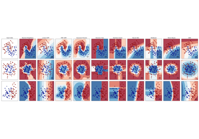

Classifier comparison

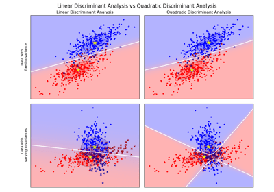

Linear and Quadratic Discriminant Analysis with covariance ellipsoid

© 2007–2022 The scikit-learn developers  
Licensed under the 3-clause BSD License.  
https://scikit-learn.org/1.1/modules/generated/sklearn.discriminant_analysis.QuadraticDiscriminantAnalysis.html